# Projekt

Kamil Zielinski 215521

14 May 2016

1. Wybieramy katalog. Należy z katalogu odczytać wszystkie pliki z rozszerzeniem csv. Tym z nich, które zawierają więcej niż 1000 wierszy zmieniamy nazwę dodając na początku nazwy pliku ”1000+”.

Uwaga: W folderze mamy tylko jeden plik co ma wiecej niz 1000 lini, jest nim dane0.csv

```r
zad1 = function() {
  fileList = list.files(pattern = "*.csv")
  for (i in 1:length(fileList))  {
    currentFile = read.csv(fileList[i])
    if (nrow(currentFile) > 1000) {
      newName = paste("1000+",fileList[i], sep = "")
      file.rename(fileList[i],newName)
      print(paste("Zmieniono nazwe pliku z",fileList[i],"na",newName))
    }
  }
}
```

```r
zad1()
```

```
## [1] "Zmieniono nazwe pliku z daneO.csv na 1000+daneO.csv"
```

```r
zad2 = function() {
  ciag = c(1,3,5,6,8,12,24,53,120,43,532,100)
  zbrior_srednich = c()

  for (i in 1:1000) {
    wylosowaneWartosci = sample(ciag,5)
    sredniaWylosowanychWartosci = mean(wylosowaneWartosci)
    zbrior_srednich = c(zbrior_srednich,sredniaWylosowanychWartosci)
  }

  hist(
    zbrior_srednich,
    col = heat.colors(10),
    main = "Histogram uzyskanych srednich",
    ylab = "Czestotliowsc",
    xlab = "Zbior srednich"
  )
}
```

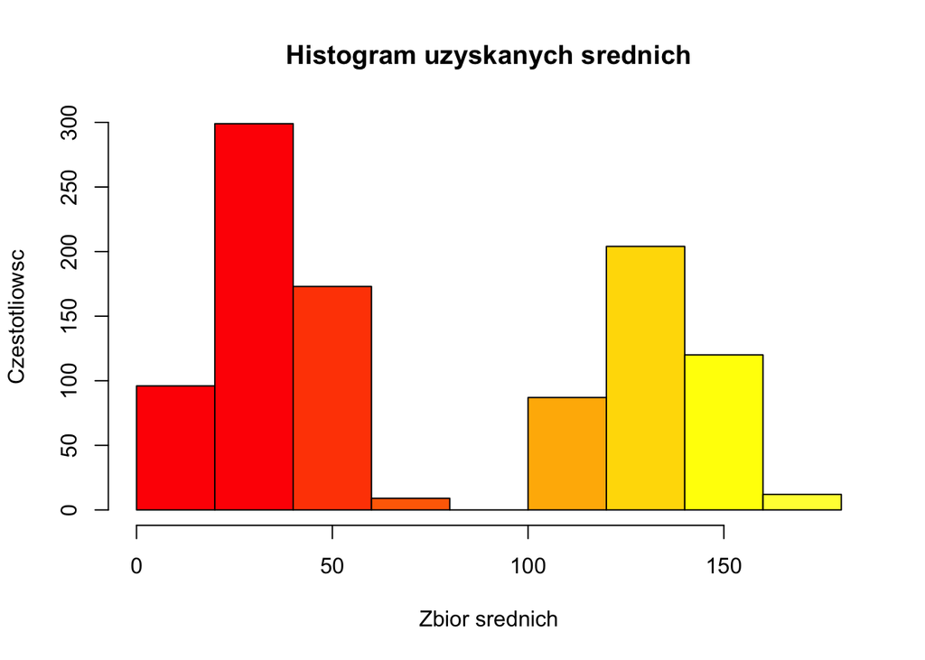

```r
zad2()
```

3. Należy wczytać z klawiatury ciąg 10 liczb i wygenerować wszystkie możliwe ciągi 4-elementowe złożone z wczytanych liczb (dopuszczalne powtórzenia). Dla każdego ciągu należy obliczyć średnią i zapamiętać ją a następnie średnie te należy pokazać na histogramie.

```r
zad3 = function() {
  ciag = c(1,3,5,6,8,12,24,53,120,43,532,100)
  zbrior_srednich = c()
  wygenerowaneMozliweCiagi = combn(ciag,4) # i wygenerować wszystkie możliwe ciągi 4-elementowe złożone z wczytanych liczb

  for (i in 1:ncol(wygenerowaneMozliweCiagi)) {
    zbrior_srednich = c(zbrior_srednich,mean(wygenerowaneMozliweCiagi[,i]))
  }

  hist(
    zbrior_srednich,
    col = rainbow(10),
    main = "Srednie wyliczone z mozliwych kombinacji 4 elementowych",
    ylab = "Czestotliowsc",
    xlab = "Zbior srednich"
  )
}
```

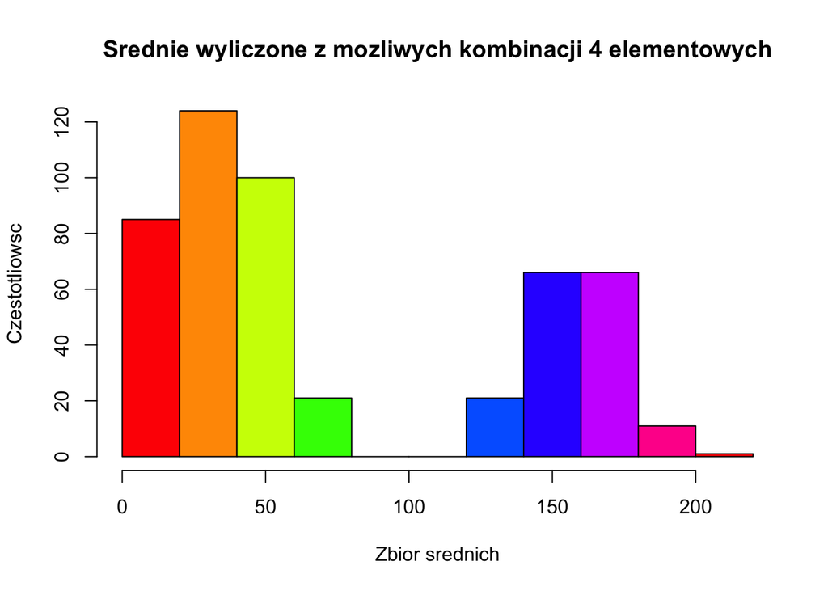

```r
zad3()
```

5. Wylosować 11 wartości z rozkładu normalnego N (0, 1) i zapamiętać je w wektorze W . Wykonać 10000 razy eksperyment polegający na wylosowaniu 11-elementowego ciągu o wartościach z wektora W (powtórzenia dopuszczalne). Dla każdego loso- wania należy wyliczyć jego medianę. Zapamiętane mediany należy zaprezentować na histogramie.

```r
zad5 = function() {
  W = rnorm(11)
  zapamietaneMediany = c()
  for (i in 1:10000) {
    wylosowana11 = sample(W,11,replace = TRUE)
    zapamietaneMediany = c(zapamietaneMediany, median(wylosowana11))
  }
  hist(
    zapamietaneMediany,
    col = terrain.colors(10),
    main = "Histogram wyliczonych median",
    ylab = "Czestotliowsc",
    xlab = "Wartosc mediany"
  )
}
```

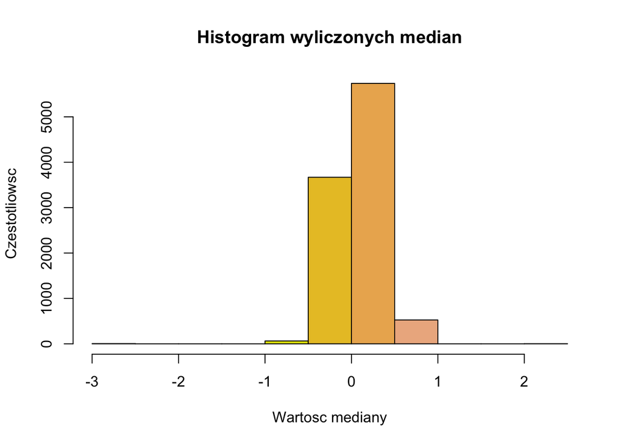

```r
zad5()
```

Do nastepnego zadania jest potrzeba nastepujaca paczka

```r
 # install.packages("readxl")
```

6. Dla tablic trwania życia ze stron Głównego Urzędu Statystycznego (http://demografia. stat.gov.pl/bazademografia/TrwanieZycia.aspx) należy wczytać dane z pli- ku(ów) oraz narysować wykresy prawdopodobieństwa zgonu qx osobno dla kobiet oraz mężczyzn w wieku 20 lat w latach 1990-2014.

```r
zad6 = function() {
  library(readxl)
  sheets = c(1990:2014)
  qxKobiet = c()
  qxMezczyzn = c()
  for (sheett in sheets) {
    rok1990 = read_excel("lifetables1990-2014.xls", sheet = as.character(sheett))
    rok1990 = rok1990[-1,] # usuniecie pierwszego wiersza
    rok1990[4] = lapply(rok1990[4],as.numeric) # cast to numeric
    rok1990[2] = lapply(rok1990[2],as.numeric) # cast to numeric
    kobiety = rok1990[rok1990$`Płeć        1-mężcz.      2-kobiety` > 1.1,]
    qx20LetniejKobiety = kobiety[kobiety$Wiek == 20,4]
    qxKobiet = c(qxKobiet, qx20LetniejKobiety)

    mezczyzni = rok1990[rok1990$`Płeć        1-mężcz.      2-kobiety` <
                          1.1,]
    qx20LetniegoFaceta = mezczyzni[mezczyzni$Wiek == 20,4]
    qxMezczyzn = c(qxMezczyzn, qx20LetniegoFaceta)
  }

  plot(
    sheets,
    qxMezczyzn,
    type = "l",
    col = "blue",
    ylab = "",
    xlab = ""
  )
  par(new = TRUE)
  plot(
    sheets,
    qxKobiet,
    type = "l",
    axes = F,
    col = "pink",
    ylab = "Prawdopobienstwo",
    xlab = "Lata",
    main = "Prawdopodobienstwo zgonu kobiet i mezczyzn w wieku 20 lat"
  )
  par(new = F)
  legend("topright", c("kobieta","mezczyzna"), bty="n", fill=c("pink","blue"));
}
```

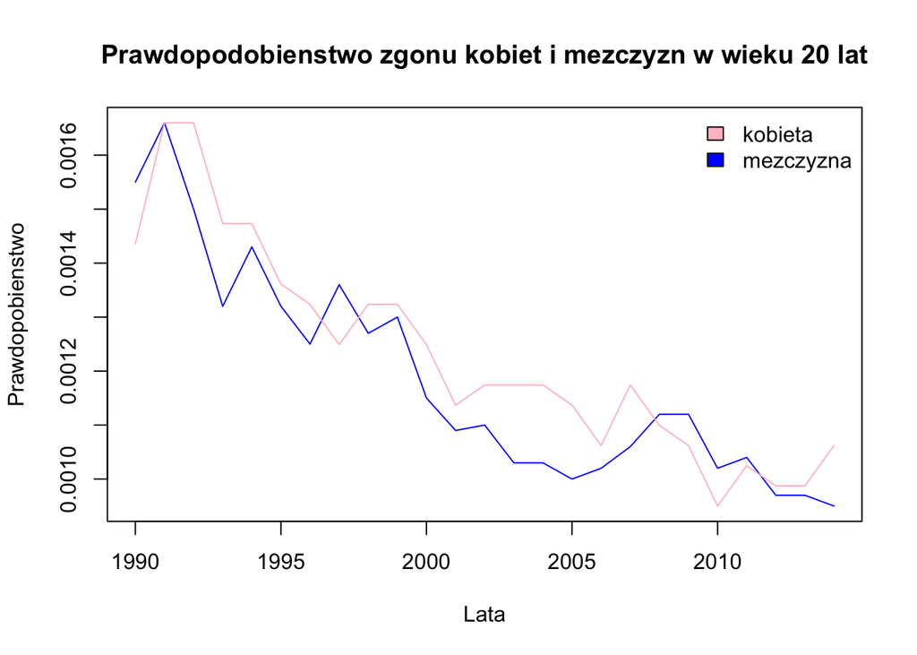

```r
zad6()
```

8. Wykorzystując dane ze zmiennej anscombe zademonstrować obliczanie parametrów regresji liniowej.

```r
zad8 = function() {
  x1 = anscombe$x1
  y1 = anscombe$y1
  regresja = lm(x1 ~ y1)
  intercept = regresja$coefficients[1]
  coefficientsY1 = regresja$coefficients[2]
  plot(x1,y1,main = "Regresja liniowa stosunku x1 do y1")
  abline(intercept,coefficientsY1,col = "red")
}
```

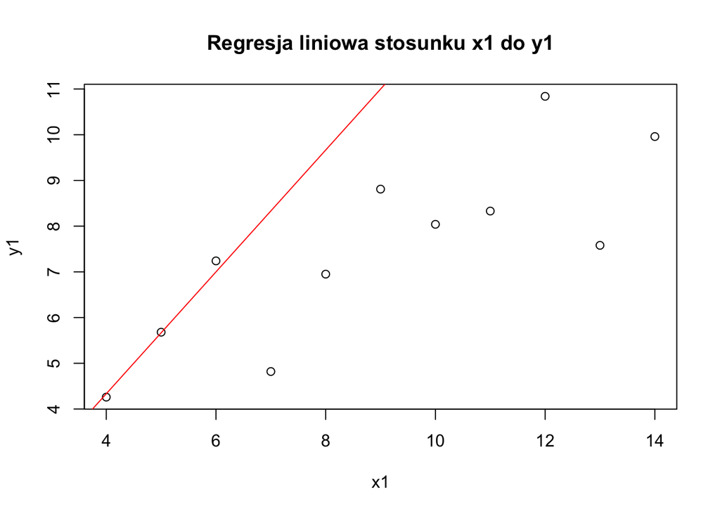

```r
zad8()
```

10. Napisać funkcję, która symuluje działanie gry Parrondo polegającej na tym, że w każdym kroku losujemy pomiędzy jedną z gier A lub B (opisanych poniżej). Po każdym kroku nasz kapitał (początkowo 0) zmienia się o +1 lub −1. Gra A to rzut monetą z wygraną (+1) z prawdopodobieństwem pA < 0.5 (podanym jako parametr pA funkcji). Gra B polega na tym, że w sytuacji gdy nasz aktualny kapitał jest podzielny przez 3, rzucamy monetą, która daje wygraną z prawdopodobieństwem pB < 0.1 (podanym jako parametr pB funkcji), w przeciwnym razie rzucamy monetą, która daje wygraną z prawdopodobieństwem pC < 0.75 (podanym jako parametr pB funkcji). Dla danej gry wykonujemy 1000 kroków i sprawdzamy czy zakończyła się wygraną (kapitał nieujemny) czy przegraną (kapitał ujemny). Należy wykonać 1000 symulacji i zliczyć wygrane oraz przegrane.

```r
zad10 = function() {
  podsumowanie = data.frame()

  parrondo = function() {
    kapital = 0

    graA = function(pA) {
      # pA < 0.5
      # print("gra A")
      wynikRzutuMoneta = rbinom(1, size = 1, prob = pA) # rzut moneta
      # print(paste("Wynik rzutu moneta z prob = ",pA," rowna sie ",wynikRzutuMoneta))
      if (wynikRzutuMoneta > 0) {
        kapital <<- kapital + 1
      } else {
        kapital <<- kapital - 1
      }
    }

    graB = function(pB, pC) {
      # pB < 0.1, pC < 0.75
      # print("gra B")
      if (kapital %% 3 == 0) {
        graA(pB)
      } else {
        graA(pC)
      }
    }

    graj = function() {
      # logika ktora gre wybrac
      for (i in 1:1000) {
        # print(paste("Gram, kapital == ", kapital))
        ktoraGra = runif(1)
        if (ktoraGra < 0.5) {
          graA(runif(1,min = 0,max = 0.5)) # 1 param
        } else {
          graB(runif(1,min = 0,max = 0.1),
               runif(1,min = 0,max = 0.75)) # podaj 2 parametry
        }
      }
    }

    graj()

    wygral = 0
    if (kapital > 0) {
      wygral = 1
    }

    return(list(wygral,kapital))
  }

  for (i in 1:1000) {
    podsumowanie = rbind(podsumowanie,parrondo())
  }
  setNames(podsumowanie,c("czyWygral","kapital"))

  print(paste("Ilosc PORAZEK =",length(podsumowanie[0 == 0,1])))
  print(paste("ilosc WYGRANYCH =",length(podsumowanie[0 == 1,1])))
}
```

```r
zad10()
```

```
## [1] "Ilosc PORAZEK = 1000"
## [1] "ilosc WYGRANYCH = 0"
```

11. Symulacja ruiny gracza w ruletkę. Zakładamy, że gracz obstawia jedynie czarne lub czerwone i stawka (oraz wygrana) mają wartość 1. Na wejściu mamy kapitał K gracza (będący liczbą całkowitą). Symulacja kończy się w sytuacji gdy gracz przegra wszystko lub osiągnie podany cel Kmax. Cel domyślnie równy jest 2K. Przy pomocy zbudowanej funkcji zademonstrować przykładową trajektorię oraz wykonać 1000 symulacji pokazując liczbę porażek oraz liczbę zwycięstw wraz ze średnim czasem do porażki lub wygranej.

```r
zad11 = function() {
  kapital = 100
  czarne = c(2,4,6,8,10,11,13,15,17,20,22,24,26,28,29,31,33,35)
  biale = c(1,3,5,7,9,12,14,16,18,19,21,23,25,27,30,32,34,36)
  podsumowanie = data.frame()

  graj = function(kapitalK) {
    kMax = 2 * kapitalK
    iloscIteracji = 0
    repeat {
      iloscIteracji = iloscIteracji + 1
      kapitalK = kapitalK - 1 #oplata za obstawienie koloru
      ktoryKolor = runif(1)
      wylosowanyNumer = sample(1:36,1)

      if (wylosowanyNumer %in% czarne && ktoryKolor < 0.5) {
        # obstawilem czarne i trafilem
        kapitalK = kapitalK + 1
      } else if (wylosowanyNumer %in% biale && ktoryKolor > 0.5) {
        # obstawilem bialem i trafilem
        kapitalK = kapitalK + 1
      }

      if (kapitalK == 0 || kapitalK == kMax) {
        wygral = 0
        if (kapitalK == kMax) {
          wygral = 1
        }
        return(list(wygral,iloscIteracji))
        break
      }
    }
  }

  for (i in 1:1000) { podsumowanie = rbind(podsumowanie,graj(kapital)) }
  setNames(podsumowanie,c("czyWygral","iloscIteracji"))

  sredniCzas = if (is.na(mean(podsumowanie[0 == 0,2]))) 0 else mean(podsumowanie[0 == 0,2])
  print(paste("Ilosc PORAZEK =",length(podsumowanie[0 == 0,1]),", sredni czas = ",sredniCzas))

  sredniCzas = if (is.na(mean(podsumowanie[0 == 1,2]))) 0 else mean(podsumowanie[0 == 1,2])
  print(paste("ilosc WYGRANYCH =",length(podsumowanie[0 == 1,1]),", sredni czas = ",sredniCzas))
}
```

```r
zad11()
```

```
## [1] "Ilosc PORAZEK = 1000 , sredni czas =  200.135"
## [1] "ilosc WYGRANYCH = 0 , sredni czas =  0"
```